# TAP 01

Author

291928

```r
library(tidyverse)
library(dplyr)
library(ggplot2)
library(datawizard)
library(broom)
library(ggfortify)
library(patchwork)
library(kableExtra)
# load the data here

tap_learning_statistics<- read.csv("/cloud/project/data/tap_learning_statistics.csv")

learning_statistics <- tap_learning_statistics
```

## **Analysis plan**

Regarding the provided hypothesis it is assumed that there is a negative linear relationship between students’ performance on the statistics module and both general anxiety and statistics anxiety. Hence, due to this linearity, a generalized linear model will be an appropriate fit for testing this hypothesis. Also, since two predictors are introduced (general anxiety and statistics anxiety), a generalized linear model with multiple predictors will be applied to this analysis. So, to test the following hypothesis:

- $H_1$: students’ performance on their statistics module (`stats_exam`) will be predicted by their level of both statistics anxiety (`stats_anxiety`) and general anxiety (`gen_anxiety`). Both types of anxiety should have a negative relationship with performance on the statistics assignment.

The following model will be fitted:

$$\hat{performance_i} = \hat{b_0} + \hat{b_1}general \ anxiety_i \ + \hat{b_2}statistics \ anxiety_i \ + \varepsilon_i$$

Data will be summarized and visualized as follows:

- Descriptive statistics (mean, standard deviation, inter-quartile range, skewness, kurtosis, and confidence intervals) of statistics anxiety (`stats_anxiety`), general anxiety (`gen_anxiety`), and performance on statistical module (`stats_exam`) will be provided to explore distributional properties and central tendencies related to data.
- Histograms of general anxiety (`gen_anxiety`), statistics anxiety (`stats_anxiety`), and students’ performance on the statistics module (`stats_exam`) to explore their distribution pattern and outliers.
- Box plots for general anxiety (`gen_anxiety`), statistics anxiety (`stats_anxiety`), and students’ performance on the statistics module (`stats_exam`) to explore possible outlier data.
- Table of outlier data using standardized residuals using the criteria of: $z \geq 2.58 \ or \ z \leq -2.58$ to define outlier data with a $99\%$ confidence level.
- Scatter plots of general anxiety (`gen_anxiety`) against srudents’ performance in the statistics module (`stats_exam`) and statistics anxiety (stats_anxiety) against srudents’ performance in the statistics module (`stats_exam`) to verify the linearity assumption for a generalized linear model.
- Scatter plot of leverage (x-axis) against standardized residuals (y-axis) will be utilized to highlight influential cases.

The generalized linear model will be fit. To check the generalizability of our results and to ensure that the utilized model is proper, assumptions of a generalized linear model should be checked as follows:

- **Linearity:** Since we are fitting a generalized linear model, it is the most important assumption. The relationship between predictor variables (general anxiety (gen_anxiety) and statistics anxiety (stats_anxiety)) and outcome variables (students’ performance on the statistics exam (stats_exam)) should be linear. This assumption will be evaluated using Scatter plots of general anxiety (`gen_anxiety`) against srudents’ performance on the statistics module (`stats_exam`) and statistics anxiety (stats_anxiety) against srudents’ performance on the statistics module (`stats_exam`). Additionally, a scatter plot of fitted values (x-axis) against the residual values (y-axis) would be used as further evidence for linearity.
- **Homoscedasticity:** The variance of residuals should be consistent at different levels of the predictor variable. To check this assumption a scatter plot of fitted values (x-axis) against residuals (y-axis) will be utilized.
- **Independence:** The residual of one case should not be predicted based on the residual of another case. To check this assumption, a scatter plot of case number (x-axis) against standardized residual values (y-axis) would be used. Residuals should be randomly scattered over the length of the x-axis.
- **Normality:** Normality of model errors (residuals) should be assessed. Since the sample size is large enough, the normality of sampling distribution due to the central limit theorem (CLT) is assumed without further checking. To check the normality, a q-q plot of standardized residuals will be utilized.

Contingency plans if any of the assumptions are not met:

- **Linearity:** If this assumption is violated, the generalized linear model would not fit anymore and there is a need to utilize non-linear models.
- **Homoscedasticity:** If this assumption is violated, while estimates of betas would not impacted, standard error will become incorrect which makes p-value, t-value, and confidence intervals incorrect. In the scenario, robust models or bootstrapping should be utilized.
- **Independence:** If this assumption is violated, a multilevel model should be utilized.
- **Normality:** If this assumption is violated, robust models or bootstrapping should be utilized.

If the assumptions are met, then the fitted generalized linear model is appropriate and results are interpretable and generalizable. For interpretations, $\alpha > 0.05$ will be used as a significance criterion. However, if the assumptions are not met, a robust model of the generalized linear model will be used. Again, for this model, $\alpha > 0.05$ will be used as a significance criterion. Also, to ensure the validity of the p-value, confidence intervals will be checked to ensure that they are not crossing zero in both scenarios (with and without meeting assumptions).

## Coding

#### Summary statistics and data visualization

```r
# Descriptive statistics of statistics anxiety
# Descriptive statistics of general anxiety
# Descriptive statistics of module performance

descriptive_variables <- learning_statistics |>
  datawizard::describe_distribution(
    c(stats_anxiety,gen_anxiety,stats_exam),
    range = FALSE,
  )

descriptive_variables <- kableExtra::kable(descriptive_variables)

# Descriptive statistics of module performance grouped by universities

descriptive_uni_grouped <- learning_statistics |>
  group_by(uni) |>
  datawizard::describe_distribution(
    stats_exam,
    range = FALSE
    )

# Histogram of statistics anxiety

hist_stats_anxiety <- ggplot(learning_statistics, aes(stats_anxiety)) +
  geom_histogram(binwidth = 1, fill = "#4682b4") +
  labs(x = "Statistics Anxiety", y = "Density") +
  theme_bw()

# Histogram of general anxiety

hist_general_anxiety <- ggplot(learning_statistics, aes(gen_anxiety)) +
  geom_histogram(binwidth = 1, fill = "#4682b4") +
  labs(x = "General Anxiety", y = "Density") +
  theme_bw()

# Histogram of module performance

hist_stats_exam <- ggplot(learning_statistics, aes(stats_exam)) +
  geom_histogram(binwidth = 1 , fill = "#4682b4") +
  labs(x = "Students' Performance" , y = "Density") +
  theme_bw()

# Box plot of statistics anxiety

box_stats_anxiety <- ggplot(learning_statistics, aes(stats_anxiety)) +
  geom_boxplot(fill = "#ff6347") +
  labs(x = "Statistics Anxiety") +
  theme_bw()

# Box plot of general anxiety

box_general_anxiety <- ggplot(learning_statistics, aes(gen_anxiety)) +
  geom_boxplot(fill = "#ff6347") +
  labs(x = "General Anxiety") +
  theme_bw()

# Box plot of module performance

box_stats_exam <- ggplot(learning_statistics, aes(stats_exam)) +
  geom_boxplot(fill = "#ff6347") +
  labs(x = "Students' Performance") +
  theme_bw()

# Table of outlier data

learning_statistics <- learning_statistics |>
  dplyr::mutate(
    z_stats_performance = (stats_exam - mean(stats_exam, na.rm = T)) / sd(stats_exam, na.rm = T)
  )

exam_outlier <- learning_statistics |>
  dplyr::filter(
    dplyr::if_any(
      .cols = z_stats_performance,
      .fn = \(column) abs(column) >= 2.58
    )
  )

exam_outlier <- kableExtra::kable(exam_outlier)

# Scatter plot of statistics anxiety against module performance

scat_stats_exam <- ggplot(learning_statistics, aes(stats_anxiety, stats_exam)) +
  geom_point(alpha = 0.8) +
  geom_smooth(method = "lm") +
  labs(x = "Statistics Anxiety" , y = "Students Performance") +
  theme_bw()

# Scatter plot of general anxiety against module performance

scat_general_exam <- ggplot(learning_statistics, aes(gen_anxiety, stats_exam)) +
  geom_point(alpha = 0.8) +
  geom_smooth(method = "lm") +
  labs(x = "General Anxiety" , y = "Students Performance") +
  theme_bw()
```

#### Statistical model

```r
# fitting the general linear model

stats_performance_lm <- lm(stats_exam ~ gen_anxiety + stats_anxiety, data = learning_statistics)

# make the results tidy and adding confidence intervals

inf_stats_oerformance_lm <- broom::tidy(stats_performance_lm, conf.int = TRUE)
```

#### Model assumptions

```r
# Influential cases

Influential_cases <- ggplot2::autoplot(stats_performance_lm, which = 5)

# Linearity and Homoscedasticity assumptions

linearity_homoscedasticity <- ggplot2::autoplot(stats_performance_lm, which = 1)

# Independence (standardized residuals should be made first)

learning_statistics$model_residuals <- stats_performance_lm$residuals

learning_statistics$standardized_model_residuals <- learning_statistics$model_residuals / sd(learning_statistics$model_residuals)


independece_scatter <- ggplot(learning_statistics, aes(id , standardized_model_residuals)) +
  geom_point() +
  geom_smooth() +
  labs(x = "case id" , y = "Standardized Residuals")


# Normality

normality_model <- ggplot2::autoplot(stats_performance_lm, which = 2)
```

#### Robust Model

```r
robust_model_stats <- parameters::parameters(stats_performance_lm, vcov = "HC4")
robust_model_stats <- kableExtra::kable(robust_model_stats, digits = 2)
```

## **Report**

#### Summary statistics and data visualization

```r
descriptive_variables
```

Table 1

| Variable | Mean | SD | IQR | Skewness | Kurtosis | n | n_Missing |
| --- | --- | --- | --- | --- | --- | --- | --- |
| stats_anxiety | 39.94353 | 6.908563 | 9.00 | -0.0811176 | 0.2180450 | 1576 | 0 |
| gen_anxiety | 39.79061 | 7.013407 | 9.00 | 0.1153600 | -0.0436928 | 1576 | 0 |
| stats_exam | 49.84518 | 15.817134 | 21.75 | -0.1318500 | -0.2971783 | 1576 | 0 |

The provided Table 1 shows descriptive statistics of statistics anxiety (`stats_anxiety`), general anxiety (`gen_anxiety`), and students’ performance on statistics exam (`stats_exam`). Overall, the skewness and kurtosis for these three variables are small and near 0 which means they are close to the normal distribution. Also, no missing value exists in the data.

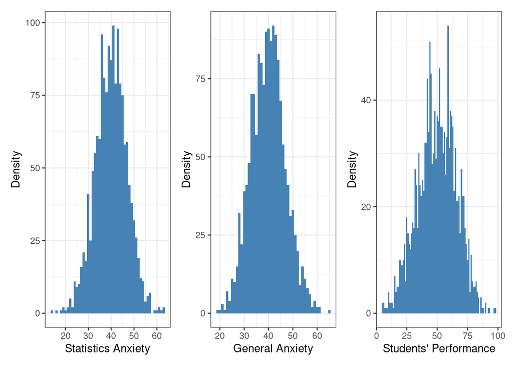

Figure 1

```r
hist_stats_anxiety + hist_general_anxiety + hist_stats_exam
```

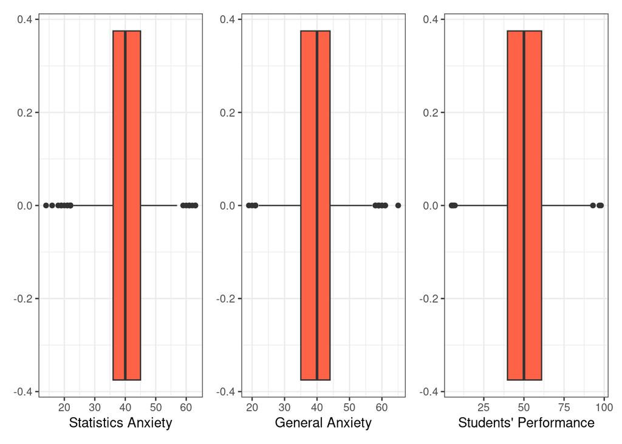

Figure 2

```r
box_stats_anxiety + box_general_anxiety + box_stats_exam
```

Illustrated box plots in Figure 2 show inter-quartile range for statistics anxiety (`stats_anxiety`), general anxiety (`gen_anxiety`), and students’ performance on statistics exam (`stats_exam`). The mean for general anxiety and statistics anxiety are close to each other (around 40) while the mean for students’ performance is near 50. Outliers are shown in these box plots with dots. As is presented the numbers of outlier cases compared to the large sample size (n = 1576) are pretty few. Consequently, it is reasonable to fit a model without much concern related to outlier cases. Also, the results general anxiety and statistics anxiety are both in the range of 0-65 which means no obvious error in data entry can be seen for these two variables.

```r
exam_outlier
```

Table 2

| id | uni | stats_anxiety | gen_anxiety | stats_exam | community | z_stats_performance |
| --- | --- | --- | --- | --- | --- | --- |
| i0024 | University 15 | 44 | 38 | 97 | In person | 2.981250 |
| i0137 | University 10 | 50 | 34 | 6 | None | -2.772005 |
| i0204 | University 10 | 53 | 45 | 6 | None | -2.772005 |
| i0802 | University 11 | 50 | 50 | 9 | None | -2.582337 |
| i0881 | University 15 | 43 | 27 | 92 | In person | 2.665137 |
| i1030 | University 11 | 49 | 28 | 5 | None | -2.835228 |
| i1059 | University 3 | 49 | 37 | 7 | None | -2.708783 |
| i1109 | University 15 | 40 | 54 | 93 | In person | 2.728359 |
| i1177 | University 9 | 47 | 35 | 8 | None | -2.645560 |
| i1293 | University 4 | 37 | 52 | 98 | In person | 3.044472 |
| i1478 | University 11 | 52 | 40 | 5 | None | -2.835228 |

The Table 2 shows that only 11 cases introduced as outlier cases in accordance to their performance in the statistics exam. Again, compared to the large sample of 1576 students, 11 outliers are not going to have significant impact on model fitting. To find this outliers, $99\%$ confidence level was assumed with $z \geq 2.58 \ or \ z \leq -2.58$.

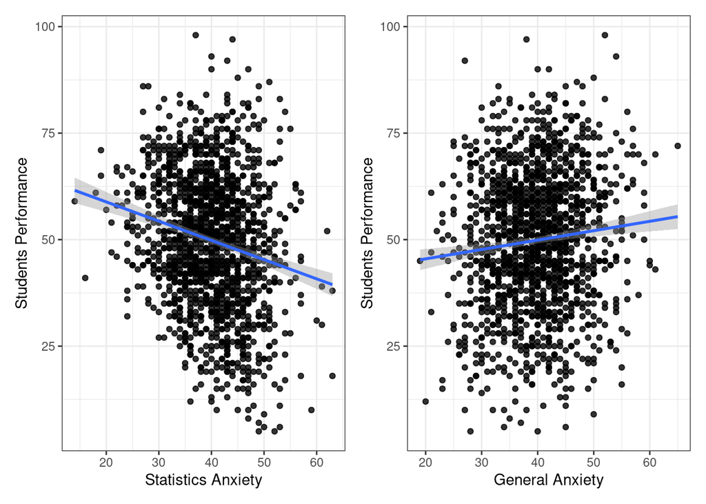

Figure 3

```r
scat_stats_exam + scat_general_exam
```

Regarding the hypothesis, a generalized linear model will be fitted. However, linearity is the major assumption of general linear model. Hence, the relationship between predictors (statistical anxiety and general anxiety) and outcome (students’ performance) should be linear. According to Figure 3 both of general anxiety and statistical anxiety are showing a linear relationship with students’ performance. However, in contrast to researchers’ hypothesis, they are not showing a same pattern in their relationships. While the relationship between general anxiety and students’ performance is positive, the relationship between statistics anxiety and students’ performance is negative. Overall, these scatter plots are showing linearity which make fitting general linear model reasonable.

#### Model Assumptions

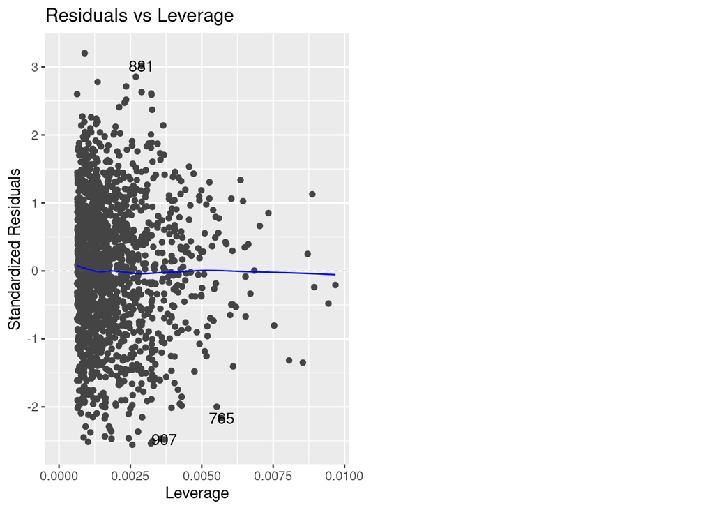

Figure 4

```r
Influential_cases
```

The threshold for leverage is calculated as: $\frac{3(p+1)}{n}$ where p is the number of predictor variables. Hence, in our case the threshold would be $0.0057$ . Since the sample size is large, and number of cases with leverage value greater than 0.0057 is limited, it is assumed that these cases would not influence the model.

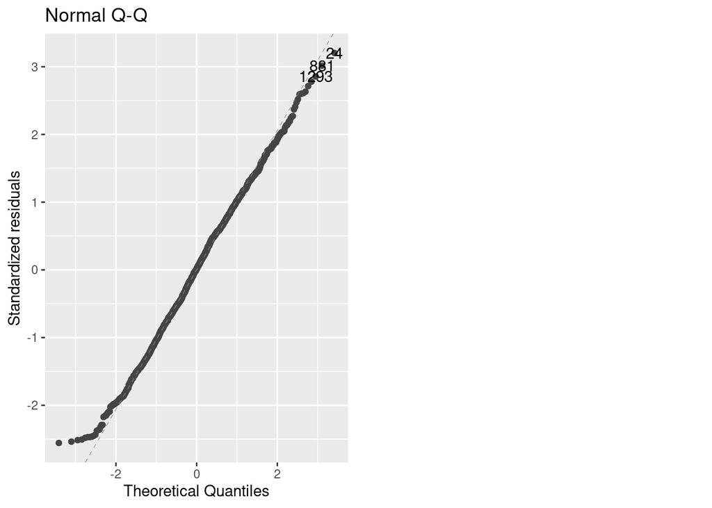

Figure 5

```r
normality_model
```

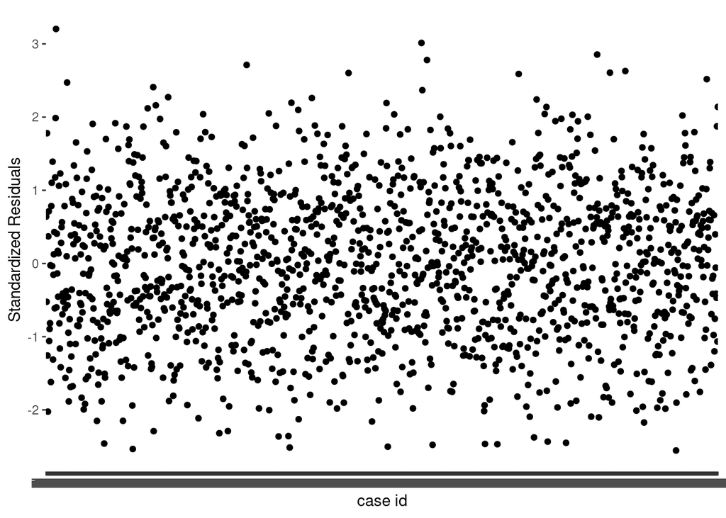

Figure 6

```r
independece_scatter
```

Independence of errors (residuals) is another assumption generalized linear model. Residual of one case should not be predicted by another case’s residual. Hence, by plotting residuals in the length of case ids (x-axis) no pattern should be seen and residuals should be scattered randomly. As is seen in Figure 6 , residuals are randomly scattered along the x-axis without following a specific pattern. Hence, the assumption of independence residuals is met.

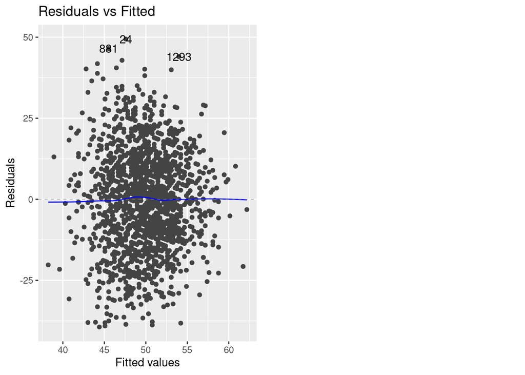

Figure 7

```r
linearity_homoscedasticity
```

#### Statistical model

```r
robust_model_stats
```

Table 3

| Parameter | Coefficient | SE | CI | CI_low | CI_high | t | df_error | p |
| --- | --- | --- | --- | --- | --- | --- | --- | --- |
| (Intercept) | 58.96 | 3.07 | 0.95 | 52.95 | 64.97 | 19.23 | 1573 | 0 |
| gen_anxiety | 0.23 | 0.06 | 0.95 | 0.12 | 0.34 | 3.99 | 1573 | 0 |
| stats_anxiety | -0.46 | 0.05 | 0.95 | -0.56 | -0.35 | -8.32 | 1573 | 0 |

According to the results of Table 3 there is a significant positive relationship between general anxiety (`gen_anxiety`) and students’ performance (`stats_exam`), $t=3.99,p<0.05$. Also, there is a significant negative relationship between statistics anxiety (`stats_anxiety`) and students’ performance (`stats_exam`), $t=-8.32,p<0.05$. However, since the sample size is significantly large, p-value cannot be a proper measure to define the significancy of the results because large samples would increase the possibility of demonstrating significant p-value without meaningful effects. For valid interpretation, beta estimates (coefficients) should be interpreted. Beta estimates for the relationship between general anxiety (`gen_anxiety`) and students’ performance (`stats_exam`) is $\hat{B} = 0.23$ which means as the general anxiety increases by one unit, the students’ performance expected to increase by 0.22 of a unit. Even though $\hat{B}=0.23$ is a low effect, but in the context of this research, this result is meaningful. According to Figure 2 the mean of students’ performance is around 50, and the IQR is around 37.5 to 62.5, hence if general anxiety increases by 10 units, students’ performance increases by 2.2 points which seems meaningful. Additionally, the confidence intervals for this beta estimate are 0.12 and 0.34 which do not cross zero. This gives us another clue to accept the significance of the p-value in reality. Beta estimates for the relationship between statistics anxiety (`stats_anxiety`) and students’ performance (`stats_exam`) is $\hat{B}=-0.46$ which means as the statistics anxiety increases by one unit, the students’ performance expected to decrease by 0.46 of a unit. This beta estimate illustrates a moderate effect. If statistics anxiety increases by 10 units, students’ performance decreases by 4.6 points which seems significantly meaningful. Additionally, the confidence intervals for this beta estimate are -0.56 and -0.35 which do not cross zero. This gives us another clue to accept the significance of the p-value in reality.

#### Summary

To sum up, the model did not support the hypothesis, that both types of anxiety should have a negative relationship with performance on the statistics exam. According to Table 3, while statistics anxiety showed a significant moderate negative relationship with students’ performance, general anxiety showed a significant low positive relationship with students’ performance. Hence, the null hypothesis ($H_0$) was approved and researchers’ hypothesis ($H_1$) was rejected.